# NbCS per article = 1

2023-10-11

## Script to work on analyses for causes paper

##Taxonomic work is needed? # Morpho differentiation types: More CS sl than CS ss overall? # Need to find expectations and test against 50:50 mark

```
##
##  Pearson's Chi-squared test with Yates' continuity correction
##
## data:  cbind(expected, observed)
## X-squared = 18.414, df = 1, p-value = 1.778e-05
```

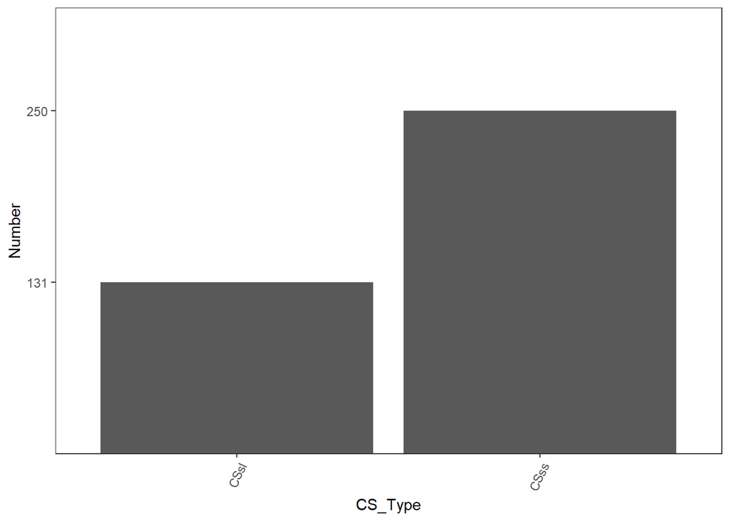

More CSss than the 50% benchmark (significant), so reject the idea that most CS are just due to taxonomic oversight.

# Available technology – More diagnostic differences in species described earlier?

```
##
##        FALSE TRUE
##   1750     4   13
##   1760     4    9
##   1770     1    4
##   1780     1    6
##   1790     1    9
##   1800     7    4
##   1810     7    5
##   1820    11   13
##   1830     8   14
##   1840     6   16
##   1850     5    6
##   1860    10   12
##   1870     5   11
##   1880     6    4
##   1890     2    6
##   1900     1   10
##   1910     0    2
##   1920     3    1
##   1930     3    6
##   1940     1    1
##   1950     1    3
##   1960     2    3
##   1970     3    3
##   1980     1    6
##   1990     5    3
##   2000     5   12
##   2010    10   15
```

```
##
##  Pearson's Chi-squared test
##
## data:  decademorpho$decade and decademorpho$CSss
## X-squared = 30.907, df = 26, p-value = 0.2317
```

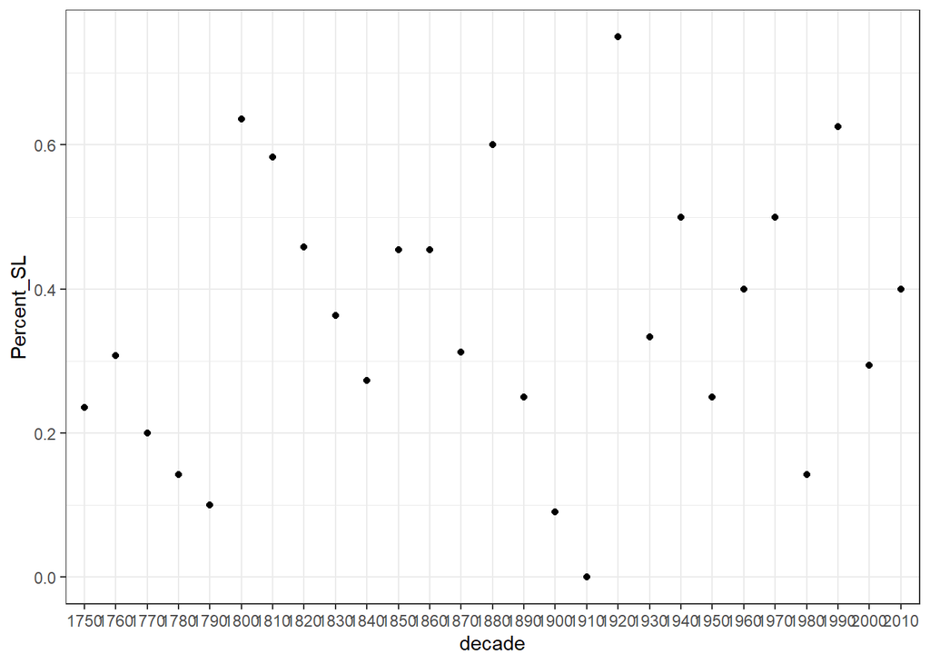

There is no trend in the percent of CSsl (diagnostic differences) through time; hypothesis not supported.

# Prevailing theories of nature and species origins - More CS in fragmented habitats in species described before Darwin?

```
##
##              1 10 100 1000 25  5
##   1756-1859  2 81   8   36 52 54
##   1860-1980  2 47  14   19 34 30
##   1981-2020  1 19   9    7 13 13
```

```
##
##  Pearson's Chi-squared test
##
## data:  breaks_HKK$decade_bin and breaks_HKK$HKK
## X-squared = 12.475, df = 10, p-value = 0.2545
```

```
##                      1        10        100      1000        25         5
## pre_Darwin 0.008583691 0.3476395 0.03433476 0.1545064 0.2231760 0.2317597
## pre_Kimura 0.013698630 0.3219178 0.09589041 0.1301370 0.2328767 0.2054795
## modern     0.016129032 0.3064516 0.14516129 0.1129032 0.2096774 0.2096774
```

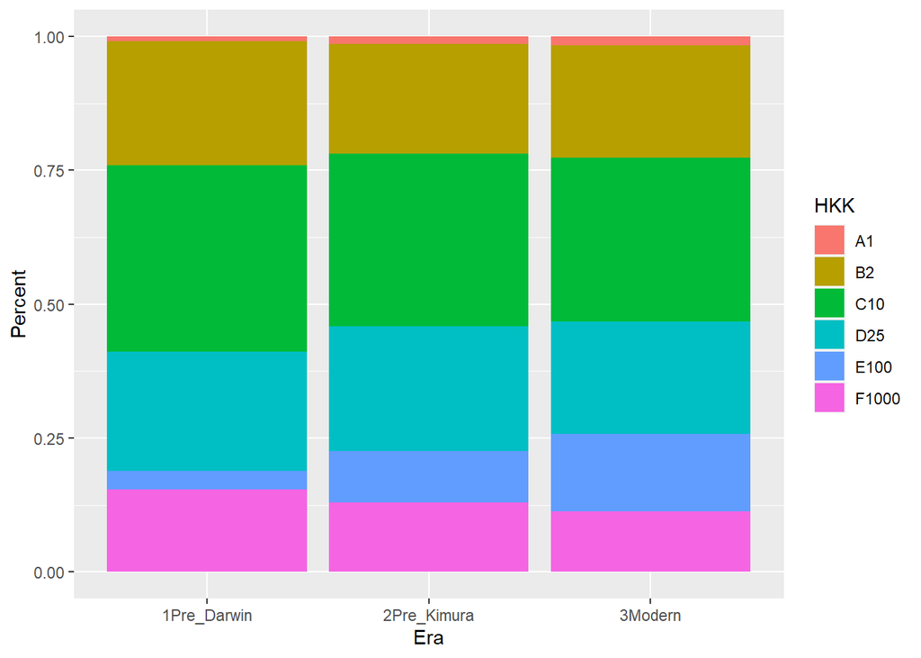

NOT SIGNIFICANT with this data subset.

# Accessibility of habitat when species described - Percentage of CS in inaccessible habitats higher in earlier spp?

```
##
##        Difficult Easy Normal
##   1750         1    9     24
##   1760         0    4     13
##   1770         2    4      7
##   1780         1    2      8
##   1790         0    5     12
##   1800         0    5     12
##   1810         0    2     13
##   1820         3    8     25
##   1830         3   12     22
##   1840         2    8     26
##   1850         0    8     19
##   1860         0   12     26
##   1870         5    3     14
##   1880         5    1     15
##   1890         0    6      7
##   1900         0    2     15
##   1910         3    2      2
##   1920         0    1      9
##   1930         1    4      8
##   1940         0    0      2
##   1950         2    0      2
##   1960         0    1      4
##   1970         1    2      4
##   1980         6    2      2
##   1990         1    2      6
##   2000         3   10     12
##   2010         3    5     21
```

```
##
##  Pearson's Chi-squared test
##
## data:  decadeAccess$decade and decadeAccess$Access
## X-squared = 107.3, df = 52, p-value = 1.023e-05
```

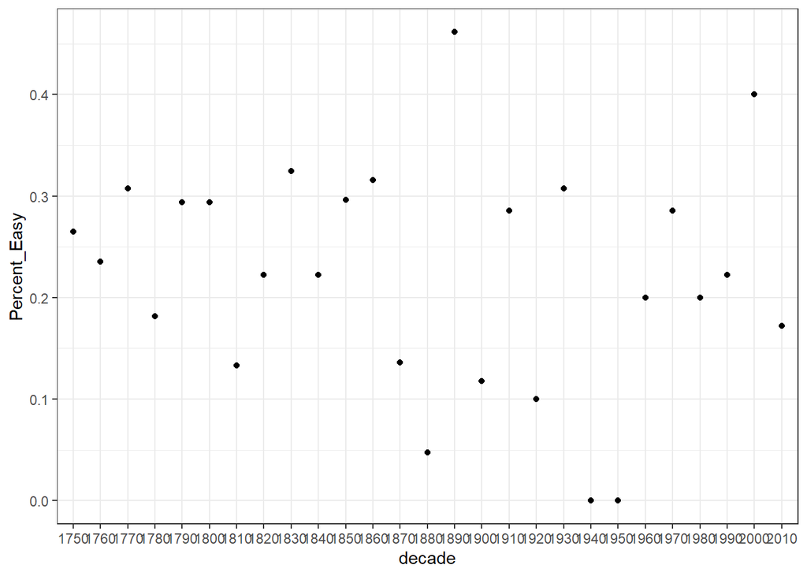

Hypothesis not supported. DIFFERENT FROM ALL SPECIES DATA but same as RIOK. Double check to see when I’m comparing all access categories vs just percent easy, but either way we don’t see clear support. (Just need to be sure when reporting p-values.)

## In sum, when we only look at species with CS (i.e. our database), the effect of taxonomic work goes away. This is interesting since that was the strongest effect in paper 1. THIS IS STILL TRUE WITH CS per article = 1.

## Effect of recent divergence - dispersal

# Larval type – Planktotrophic/pelagic larvae leads to less CS/NS)?

Note1: for this I’m working with a separate surveylarv input file where I have corrected larval types to pt, lt, dd, and removed all others, including cases where there are multiple types checked. (Most of those cases are where the two CS have different larvae.) This left 410 CS with larval info.

Note2: the data fail the homoscedasticity test (Bartlett’s) so I’ve used a nonparametric Kruskal-Wallis test to see if CS/NS is different among groups.

```
##       DD       LT       PT
## 3.727273 3.375000 3.230415
```

```
##       DD       LT       PT
## 2.617250 3.605307 3.489720
```

```
##
##  Kruskal-Wallis rank sum test
##
## data:  as.numeric(larv_NbCS$Nb_CS) and larv_NbCS$Larv_type
## Kruskal-Wallis chi-squared = 8.3086, df = 2, p-value = 0.0157
```

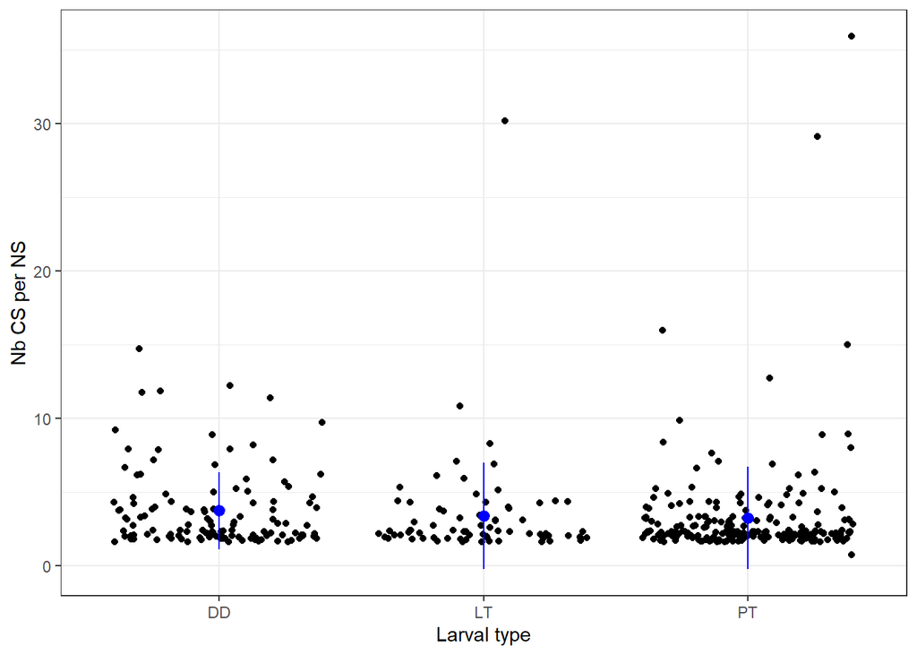

Hypothesis supported, with DD having higher mean CS per nominal species. This is the same as all species and different from RIOK=TRUE.

# High HKK leads to more CS ss – testing this based on Nb_CS per HKK.

Note: data again failed homoscedasticity, using Kruskal Wallis test

```
##        1        5       10       25      100     1000
## 2.857143 3.400000 3.582353 3.121739 3.435897 3.441558
```

```
##        1        5       10       25      100     1000
## 1.214986 2.182436 3.399745 2.979897 1.997299 4.336180
```

```
##
##  Kruskal-Wallis rank sum test
##
## data:  HKK_NbCS$Nb_CS and HKK_NbCS$HKKv3
## Kruskal-Wallis chi-squared = 4.5316, df = 5, p-value = 0.4757
```

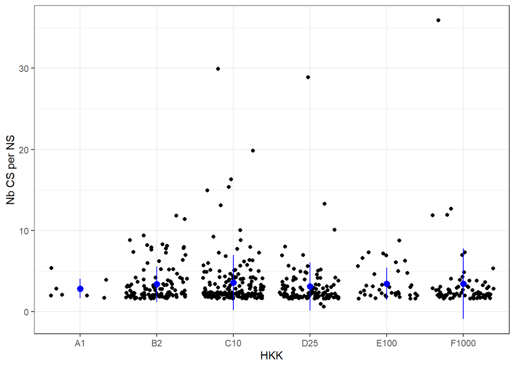

Result: Ok, this looks like the whole dataset again. No clear / significant trend.

## In sum, again the support for the role of recent divergence as measured by a proxy of dispersal depends on what the proxy is. Support with larval type, not with HKK. Same as all_species dataset.

# More stable environments = more CSss or statistical differences

Note: stable = pelagic, deepsea, cave, coralreef; not stable = coastal, intertidal, estuarine, seagrass

```
##
##         FALSE TRUE
##   FALSE    92   39
##   TRUE    152   98
```

```
##
##  Pearson's Chi-squared test with Yates' continuity correction
##
## data:  stable_hab$CSss and stable_hab$Stable
## X-squared = 2.9218, df = 1, p-value = 0.08739
```

```
##                FALSE      TRUE
## CSss_total 0.6229508 0.7153285
## CSsl_total 0.3770492 0.2846715
```

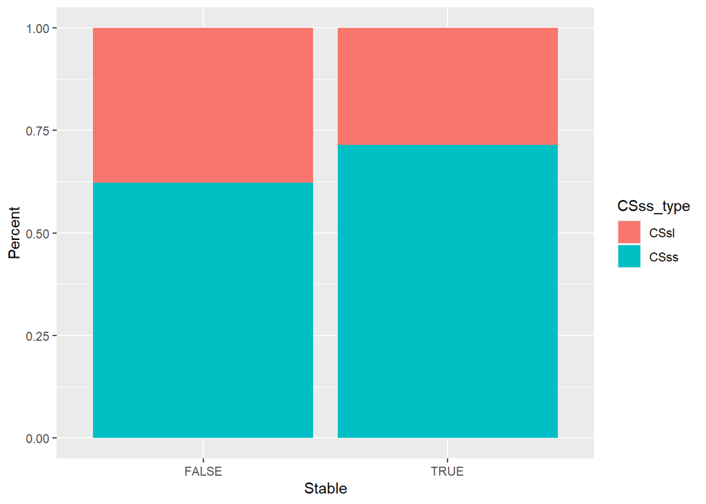

Result: More CSss found in stable environments, though p-value is marginal with this subset of data. Hypothesis supported. Weaker support than with whole dataset OR with RIOK=TRUE.

# Note also that stabilizing selection predicts more CSss than CSsl, which is what we find (see above).

## In sum, we generally have support for this idea.

## High Ne (neutral hypotheses)

# Reproductive investment - Low reproductive investment leads to more statistical divergence? (Repro. investment proxy for Ne)

Note1: Again this uses the surveylarv dataset with hand cleaning. Note2: Planktotrophic = LOW; Lecithotrophic, Brooding, DD = HIGH; If a spp could be both low and high, have marked it NA (is usually bc the CS have different larval types). Anything else got marked NA to be conservative. Note3: Only 263 cases are considered here, meaning that is where we have morphological data AND larval type data AND NbCS/article = 1.

```
##
##                      HIGH LOW
##   Diagnostic           44  42
##   No differentiation   35  40
##   Statistic            47  55
```

```
##
##  Pearson's Chi-squared test
##
## data:  surveylarv$Morpho_diff and surveylarv$Repro_invest
## X-squared = 0.54818, df = 2, p-value = 0.7603
```

Result: not significant.

# High HKK leads to more CS ss (HKK as proxy for Ne)

```
##
##                       1  5 10 25 100 1000
##   Diagnostic          4 33 34 37   8    7
##   No differentiation  1 19 30 18  10    9
##   Statistic           0 26 47 31   7   25
```

```
##              1         5        10        25  100      1000
## stat_total 0.0 0.3333333 0.4234234 0.3604651 0.28 0.6097561
## diag_total 0.8 0.4230769 0.3063063 0.4302326 0.32 0.1707317
## nod_total  0.2 0.2435897 0.2702703 0.2093023 0.40 0.2195122
```

```
##
##    1    5   10   25  100 1000
##    5   78  111   86   25   41
```

```
##
##  Pearson's Chi-squared test
##
## data:  surveymorpho$Morpho_diff and surveymorpho$HKKv3
## X-squared = 21.987, df = 10, p-value = 0.01517
```

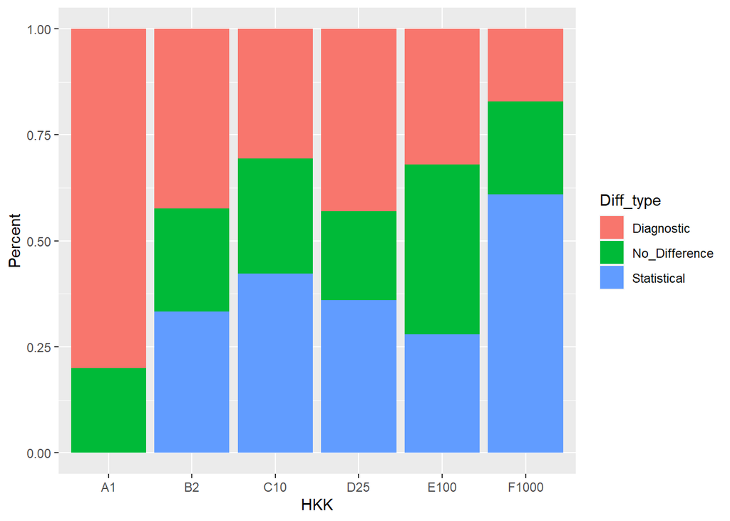

```
##
##        FALSE TRUE
##   1        4    1
##   5       33   45
##   10      34   77
##   25      37   49
##   100      8   17
##   1000     7   34
```

```
##
##  Pearson's Chi-squared test
##
## data:  surveymorpho$HKKv3 and surveymorpho$CSss
## X-squared = 15.382, df = 5, p-value = 0.008849
```

```
##              1         5        10        25  100      1000
## CSss_total 0.2 0.5769231 0.6936937 0.5697674 0.68 0.8292683
## CSsl_total 0.8 0.4230769 0.3063063 0.4302326 0.32 0.1707317
```

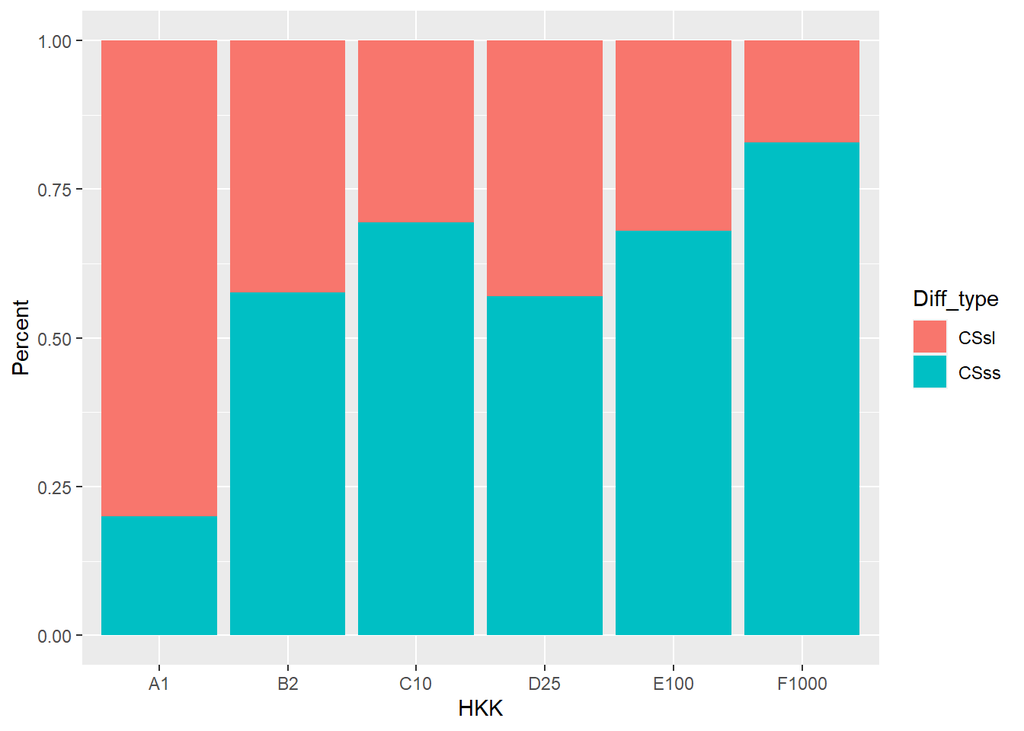

Results: More diagnostic differences (=CSsl) at lower HKK values, both when considering 3 morpho classes AND just ss vs sl. Overall p-value still significant but this pattern seems less clear. Lots more CSss at high HKK.

## In sum, we see support for the neutral hypothesis if we use HKK as a proxy for Ne but NOT if we use reproductive investment.

## Hypothesis: effect of recent divergence – More sympatric than allopatric CS/NS for a given Nsg?

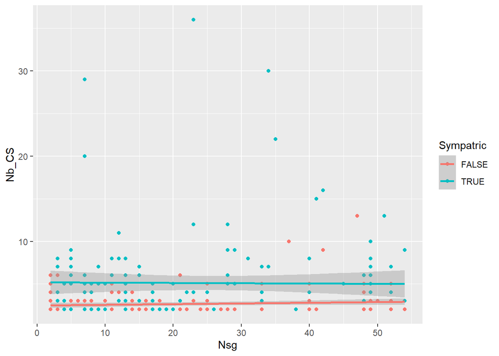

```
## ANOVA Table (type II tests)
##
##      Effect DFn DFd     F     p p<.05      ges
## 1     Nb_CS   1 330 0.083 0.773       0.000253
## 2 Sympatric   1 330 0.120 0.730       0.000362
```

These results aren’t statistically significant (ANCOVA) but the graph is in line with the hypothesis. Marginal support. HOWEVER these lines look closer together than the whole dataset or RIOK=true? Careful on interpretation.

## Selection against hybrids – More diagnostic differences in sympatry than allopatry?

```
##
##         FALSE TRUE
##   FALSE    62   31
##   TRUE     88   68
```

```
##
##  Pearson's Chi-squared test with Yates' continuity correction
##
## data:  surveymorpho$CSss and surveymorpho$Sympatric
## X-squared = 2.1487, df = 1, p-value = 0.1427
```

```
##                FALSE      TRUE
## CSss_total 0.5866667 0.6868687
## CSsl_total 0.4133333 0.3131313
```

[figure not shown]

Result: There are no longer significant associations here = different from whole dataset AND from RIOK=TRUE.

## Importance of biological traits

# More diagnostic traits with hard skeleton?

```
##
##                        N   Y
##   Diagnostic          28  96
##   No differentiation  27  69
##   Statistic           27 107
```

```
##
##  Pearson's Chi-squared test
##
## data:  surveymorpho$Morpho_diff and surveymorpho$hard_skeleton
## X-squared = 2.0355, df = 2, p-value = 0.3614
```

```
##                    N         Y
## stat_total 0.3292683 0.3933824
## diag_total 0.3414634 0.3529412
## nod_total  0.3292683 0.2536765
```

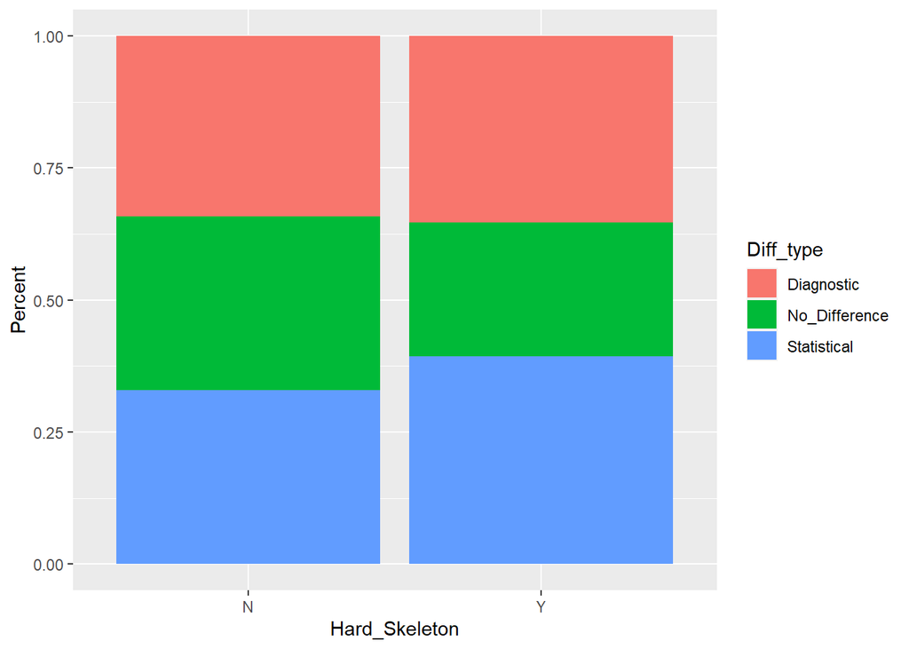

THIS IS NO LONGER SUPPORTED WHEN NbCS/article = 1. This must mean that species that were dropped in some way affected this. Investigate!

# More diagnostic traits with image vision?

```
##
##                       N  Y
##   Diagnostic         54 70
##   No differentiation 53 43
##   Statistic          62 72
```

```
##
##  Pearson's Chi-squared test
##
## data:  surveymorpho$Morpho_diff and surveymorpho$image
## X-squared = 3.1357, df = 2, p-value = 0.2085
```

Result: hypothesis not supported

# More diagnostic traits with internal fertilization?

```
##
##                       B  E  I
##   Diagnostic         39 44 41
##   No differentiation 30 47 19
##   Statistic          30 70 34
```

```
##
##  Pearson's Chi-squared test
##
## data:  surveymorpho$Morpho_diff and surveymorpho$ferti
## X-squared = 10.428, df = 4, p-value = 0.0338
```

```
##                    B         E         I
## stat_total 0.3030303 0.4347826 0.3617021
## diag_total 0.3939394 0.2732919 0.4361702
## nod_total  0.3030303 0.2919255 0.2021277
```

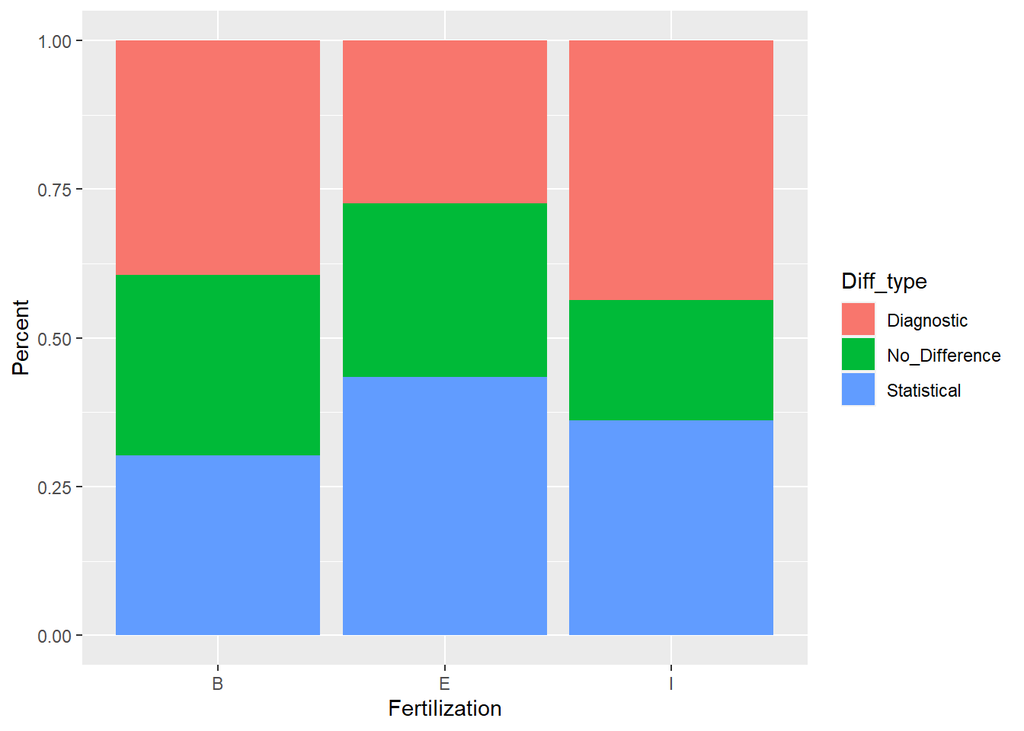

Result: hypothesis supported. Species with internal fert are more likely to have diag diffs, ie CSsl. This is also true if I remove the “both” category. Hypothesis accepted.

# More diagnostic traits with external genitalia?

```
##
##                       B  N  Y
##   Diagnostic         23 62 39
##   No differentiation 17 63 16
##   Statistic          11 91 32
```

```
##
##  Pearson's Chi-squared test
##
## data:  surveymorpho$Morpho_diff and surveymorpho$genitals
## X-squared = 14.475, df = 4, p-value = 0.005924
```

```
##                    B         N         Y
## stat_total 0.2156863 0.4212963 0.3678161
## diag_total 0.4509804 0.2870370 0.4482759
## nod_total  0.3333333 0.2916667 0.1839080
```

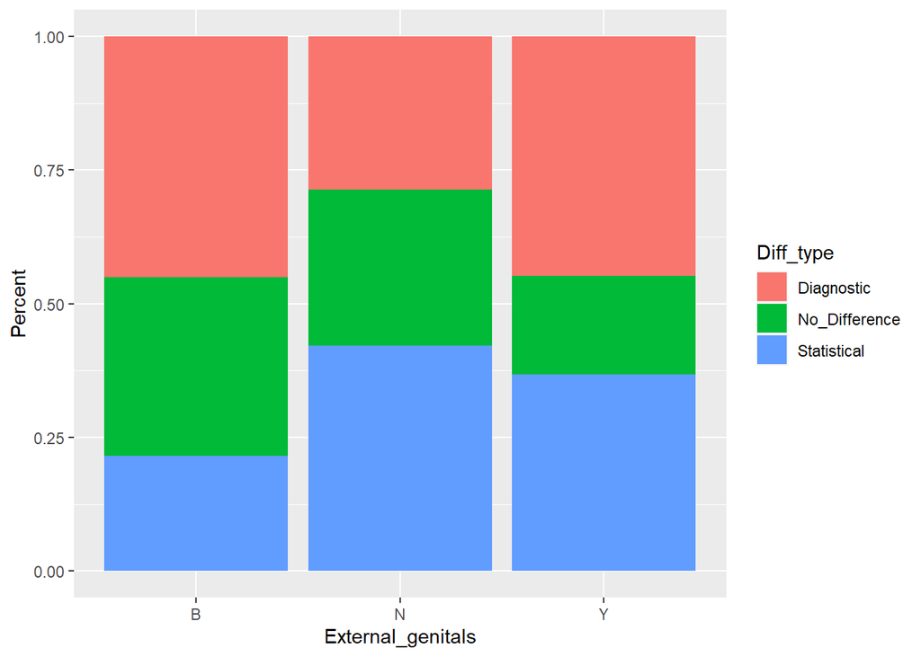

Result: more diagnostic traits with external, hypothesis accepted. This is also true if only considering CSss and CSsl, AND when gastropods are removed (the only class with “both”).

## In sum, fertilization and genitalia still have a role in determining the TYPE of CS that is found (ss vs sl) BUT the role of hard skeletons went away? Need to look into this.

## So, overall conclusions: When looking at the full dataset, there is support for several (but not all) sets of hypotheses. Interestingly, the effect of taxonomic work/effort seems to go away, while the effect of taxonomic class remains. Some support for both selection-based and neutral ideas.

## When considering NbCS per article = 1, patterns are mostly similar to the full dataset. There is slightly less support for biological factors here (skeletons) AND we no longer see more diagnostic differences in sympatry.